# Ordenando, tidy, la información sobre educación: una aplicación al Plan Ceibal en Uruguay

05-sep-2018

## Plan de la presentación

**¿Qué vamos a presentar?**

- Tidyverse
- Aplicación: Supervivencia de tablet JPCouto
- Comparación antes y despues de tidyverse
  - Importación
  - Limpieza
  - Transformación y manipulación
  - Visualización

**¿Qué *no* vamos a presentar?**

- Aplicación: Abandono estudiantil en pasaje de primaria a secundaria

## ¿Qué es tidyverse?

Tidyverse es un conjunto de paquetes de R diseñados para la ciencia de datos.

Todos los paquetes comparten una misma filosofía de datos y de programación en R y están diseñados para trabajar conjuntamente de forma natural.

Instalar el tidyverse completo con:

```r
install.packages("tidyverse")
```

Algunos de los paquetes son:

- `readr`: lectura de datos rectangulares
- `tidyr`: creación de datos limpios
- `dplyr`: transformación de datos
- `forcats`: soluciona problemas con factores
- `ggplot2`: visualización de los datos

## Aplicación al Plan Ceibal en Uruguay

- Plan Ceibal:
  - Se creó en 2007
  - Plan de inclusión e igualdad de oportunidades que apoya con tecnología las políticas educativas
  - One laptop por child (OLPC)
  - Cada niño que ingresa a la educación pública en todo el país accede a una computadora para su uso personal con conexión a Internet gratuita desde el centro educativo.
  - https://www.ceibal.edu.uy
- Análisis de supervivencia del modelo de tablet JPCouto entregado por Ceibal en 2014 y 2015 a alumnos de primaria pública: primera vida, segunda vida, …

## Importación de los datos

- Se leen los datos directo de SQL con `RODBC` y se guardan en RData's
- Los datos fueron cambiando por lo que hubo que cargarlos muchas veces, y *cada vez cambiar el informe*

```r
##Se cargan los datos (tablas) extraidos de SQLserver
load("../../Datos/prueba_201708.RData")
load("../../Datos/prueba_2_201708.RData")
load("../../Datos/datos_tablets_201708.RData")
load("../../Datos/ventas_201708_v2.RData")
```

- Alternativa: Con paquete `readr` o `DBI` para importar datos directamente de SQL Server, PostgreSQL, etc.

Se obtienen 5 tablas iniciales (comentar CRM)

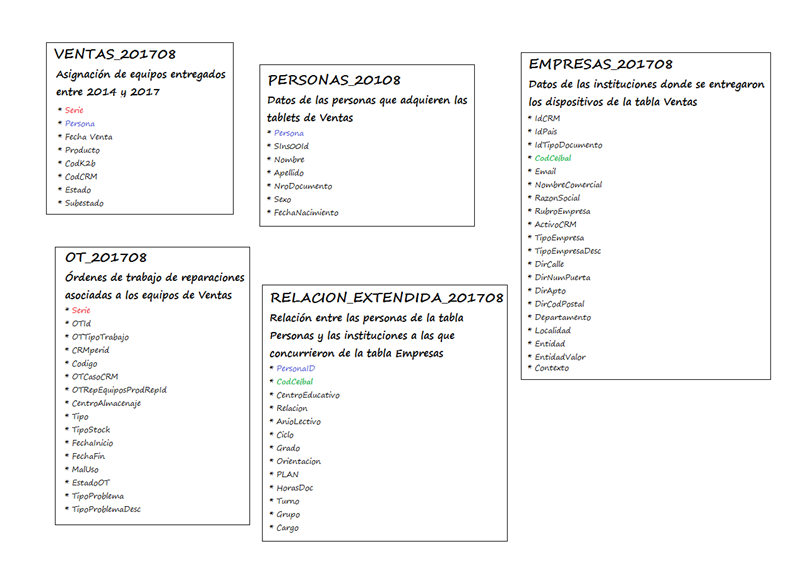

## Se limpian y ordenan los datos

Hay tres reglas interrelacionadas que hacen que un conjunto de datos sea ordenado:

- Cada variable debe tener su propia columna.
- Cada observación debe tener su propia fila.
- Cada valor debe tener su propia celda.

Por ejemplo la tabla de Relación Extendida presenta varios valores de una misma variable para la misma observacion

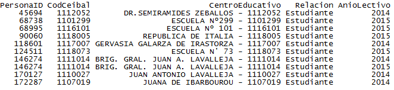

- Se utiliza el paquete `tydyr` obteniendo una fila por Persona

```r
REL_EXT_201708 %>%
    spread(key = AnioLectivo, value = CentroEducativo)
```

- Si hubiese algunos nombres de columnas que no son nombres de variables, sino valores de una variable, se utiliza la función `gather()`.

## Transformación de los datos

**Ejemplo 1:** Se filtran algunas de las tablas

```r
#Sólo modelo de tablet JPCouto (996) y año de entrega 2014 y 2015
tablet.996 <- VENTAS_201708[VENTAS_201708$CodCRM == "996",]
tablet.996 <- tablet.996[tablet.996$AnioVenta < 2016,]

#Sólo alumnos de educación primaria
alumnos <- REL_EXT_201708[REL_EXT_201708$Relacion == "Estudiante",]
primaria <- alumnos[alumnos$Ciclo == "PRIMARIA",]
```

- Con el paquete `dplyr`

```r
VENTAS_201708 %>%
  filter(CodCRM == "996", AnioVenta < "2016")

REL_EXT_201708 %>%
  filter(Relacion == "Estudiante", Ciclo == "PRIMARIA")
```

Se verifican errores e inconsistencias (trabajo de ida y vuelta con Ceibal)

**Ejemplo 2:** Hay observaciones a las cuales se les debe cambiar el contexto

```r
Emp$Contexto[Emp$CodCeibal == "1101321"] <-  "QuintilUrbano1"
Emp$Contexto[Emp$CodCeibal == "1103158"] <-  "QuintilRural2"
```

- Con el paquete `dplyr`

```r
Emp %>%
  filter(CodCeibal == "1101321") %>%
  mutate(Contexto = "QuintilUrbano1")

Emp %>%
  filter(CodCeibal == "1103158") %>%
  mutate(Contexto = "QuintilRural2")
```

**Ejemplo 3:** Se ordenan algunas de las tablas según ciertas variables

```r
OT  <- OT[order(OT$CRMperid, OT$FechaInicio, OT$Serie),]
Ven <- Ven[order(Ven$Persona, Ven$FechaVenta ,Ven$Serie),]
```

- Con el paquete `dplyr`

```r
OT %>%
  arrange(CRMperid, FechaInicio, Serie)

Ven %>%
  arrange(Persona, FechaVenta, Serie)
```

**Ejemplo 4:** Se verifica que ciertas variables (las que relacionan una tabla con otra) sean únicas

```r
table(table(Ven$Serie))
table(table(Pers$Persona))
table(table(Emp$CodCeibal))
```

- Con `tidyverse` una forma sería:

```r
Ven %>% count(Serie) %>% filter(n > 1)
Pers %>% count(Persona) %>% filter(n > 1)
Emp %>% count(CodCeibal) %>% filter(n > 1)
```

**Ejemplo 5:**

- Se pretende llegar a una única base ordenada con la información de las 5 tablas iniciales.
- Se fueron creando subconjuntos de la base (nuevas tablas), realizando `merge()` entre una y otra, creándose muchos objetos auxiliares (`aux1`, …, `aux9`), etc.
- Se llegó a una base final (PrimeraVida) ordenada: cada fila corresponde a una observación, cada columna a una variable y cada celda a un valor.

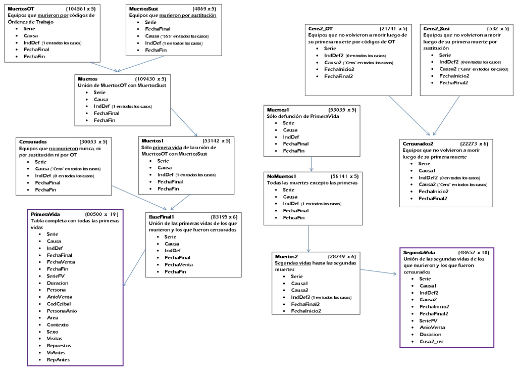

- Con `tidyverse` se podría hacer con **mutating joins** y **filtering joins**

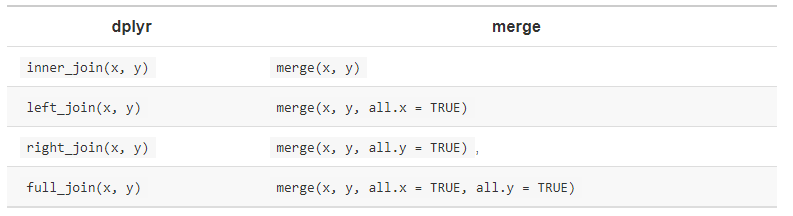

El *filtering join* une las observaciones que coinciden de la misma forma que *mutating joins*, pero afecta las observaciones, no las variables.

- `semi_join(x, y)` guarda todas las observaciones en `x` que tienen una coincidencia en `y`.
- `anti_join(x, y)` descarta todas las observaciones en `x` que tienen una coincidencia en `y`.

**Ejemplo 6_a:** Se trabaja con la recodificación de los niveles de variables categóricas

```r
PrimeraVida$Contexto   <- as.factor(PrimeraVida$Contexto)
PrimeraVida$Contexto <- factor(recode(PrimeraVida$Contexto, "1:6=6;
                               7=7; 8:=8; 9=9; 10=10 11:12=11"))
levels(PrimeraVida$Contexto) <- c("Quntil 1", "Quintil 2", "Quintil
                            3", "Quintil 4", "Quintil 5", "Rural")
```

- Con los paquetes `dplyr` y `forcats`

```r
PrimeraVida %>%
  mutate(Contexto = fct_recode(Contexto,
         "Quintil 1" = "QuintilUrbano1",
                    ...
         "Quintil 5" = "QuintilUrbano5",
         "Rural" = "QuintilRural1",
                ...
         "Rural" = "QuintilRural5",)) %>% count(Causa_rec)
```

**Ejemplo 6_b:**

```r
PrimeraVida$Causa_rec[PrimeraVida$Causa %in% c(1,2,11,101)] <- "Placa"
PrimeraVida$Causa_rec[PrimeraVida$Causa %in% c(10,100,1000,1002,
                                          2000)] <- "Modulo"
PrimeraVida$Causa_rec[PrimeraVida$Causa %in% c(1001,2002)] <-
                                             "Modulo + Placa"
PrimeraVida$Causa_rec[PrimeraVida$Causa == 555] <- "Sust"
```

- Con los paquetes `dplyr` y `forcats`

```r
PrimeraVida %>%
  mutate(Causa_rec = fct_collapse(Causa,
    Placa = c(1,2,11,101),
    Modulo = c(10,100, 1000,1002,2000),
    Modulo + Placa = c(1001,2002),
    Sust = 555
  )) %>%
  count(Causa_rec)
```

## Visualización de los datos

**Ejemplo 1:** Se quiere graficar la media y la mediana de la duración según las causas de defunción

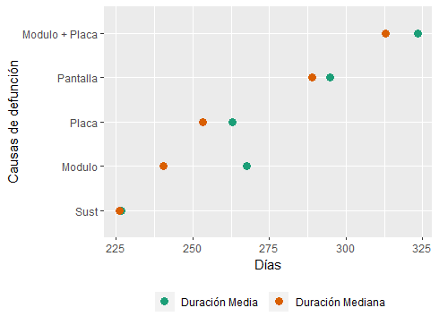

```r
Media_Causa <- data.frame(tapply(PrimeraVida$Duracion,
               PrimeraVida$Causa_rec, mean, na.rm = TRUE))
Media_Causa$Causa <- rownames(Media_Causa)
colnames(Media_Causa) <- c("Duracion_Media_Mediana", "Causa")
Media_Causa$Medida <- "Duración Media"
...

SegunCausa <- rbind(Media_Causa, Mediana_Causa)
```

```r
plot(SegunCausa$Causa, SegunCausa$Duracion_Media_Mediana,
     xlab="Días", ylab="Causas de defunción")
```

- Con los paquetes `dplyr` y `ggplot2`

```r
PrimeraVida %>%
  group_by(Causa_rec) %>%
  summarize(DurMedia=mean(Duracion), DurMediana=median(Duracion)) %>%

ggplot(aes(x=reorder(Causa_rec), color=Medida)) +
  geom_point(size=3) +
  coord_flip() +
  scale_color_brewer(palette = "Dark2", name="") +
  labs(x="Causas de defunción", y="Días") +
  theme(legend.position = "bottom")
```

**Ejemplo 2:** Se grafica las causa de defunción para cada año de entrega (en porcentajes)

Con los paquetes `dplyr`, `forcats` y `ggplot`

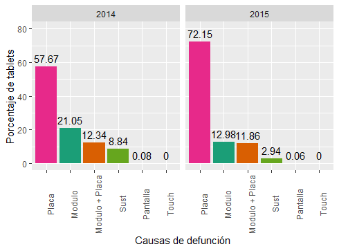

```r
PrimeraVida %>%
  select(IndDef = "Defunción") %>%
  group_by(AnioVenta,Causa_rec) %>%
  summarise(n = n()) %>%
  mutate(percent = n/sum(n, na.rm=TRUE)*100) %>%
ggplot(aes(x=fct_reorder(Causa_rec, -percent), y=percent,
           fill =Causa_rec)) +
    geom_bar(stat="identity", position="stack") +
  facet_wrap(~ AnioVenta) +
    scale_fill_brewer(palette = "Dark2") +
    labs(x = "Causas de defunción", y = "Porcentaje de tablets") +
  geom_text(aes(x=Causa_rec, label=round(percent,2), y=percent,
                vjust = -0.5)) + ylim(0,80) +
    theme(legend.position = "none",
          axis.text.x = element_text(angle = 90))
```

## Conclusiones

- más ordenado => menos errores (`aux9[,5]`)
- más fácil de implementar trabajo colaborativo (con otros y con uno mismo)
- dudas
  - ¿más rápido?
  - ¿menos RAM?